# RENR 364 Group Project Data Analysis

Version 2-1

2023-03-11

# Import

Import data set from csv file and verify import

```r
bird.dat <- read.csv("bird.data.csv")
head(bird.dat)
```

```
##   sheetID site replicate                species raw.abundance abundance urban
## 1   OS_11   LS       LS2         American Robin             1         1  high
## 2   OS_11   LS       LS2    Black-billed Magpie             3         3  high
## 3    KT_1  MCR      MCR1    Black-billed Magpie             2         2  high
## 4    KT_1  MCR      MCR1 Black-capped Chickadee             3         3  high
## 5    KT_1  MCR      MCR1               Blue Jay             2         2  high
## 6    KT_1  MCR      MCR1       Bohemian Waxwing            20         1  high
##   habitat start.month start.day start.hr start.min tempC
## 1       C           2        26       14        45    -9
## 2       C           2        26       14        45    -9
## 3       D           2        19       13         9    -6
## 4       D           2        19       13         9    -6
## 5       D           2        19       13         9    -6
## 6       D           2        19       13         9    -6
```

# Analysis

## Create Abundance Table for Replicates

Sum Abundances by Replicate

```r
replicates.abun <- bird.dat %>%
  group_by(replicate,urban,habitat) %>%
  summarize(rep.abun=sum(abundance))
replicates.abun
```

```
## # A tibble: 12 × 4
## # Groups:   replicate, urban [12]
##    replicate urban habitat rep.abun
##    <chr>     <chr> <chr>      <int>
##  1 CEL1      low   C             12
##  2 CEL2      low   C             11
##  3 CEL3      low   C             11
##  4 LHP1      low   D              7
##  5 LHP2      low   D              5
##  6 LHP3      low   D              9
##  7 LS1       high  C             15
##  8 LS2       high  C             13
##  9 LS3       high  C             14
## 10 MCR1      high  D             11
## 11 MCR2      high  D             18
## 12 MCR3      high  D              6
```

## Abundance

### Habitat

#### Mean Abundance and Error

```r
hab.stat <- bird.dat %>%
  group_by(habitat,replicate) %>%
  summarize(total.abun=sum(abundance)) %>%
  group_by(habitat) %>%
  summarize(mean.abun.hab=mean(total.abun),
            count = n(), sd=sd(total.abun),
            se=sd/sqrt(count))
head(hab.stat)
```

```
## # A tibble: 2 × 5
##   habitat mean.abun.hab count    sd    se
##   <chr>           <dbl> <int> <dbl> <dbl>
## 1 C               12.7      6  1.63 0.667
## 2 D                9.33     6  4.76 1.94
```

##### Plot

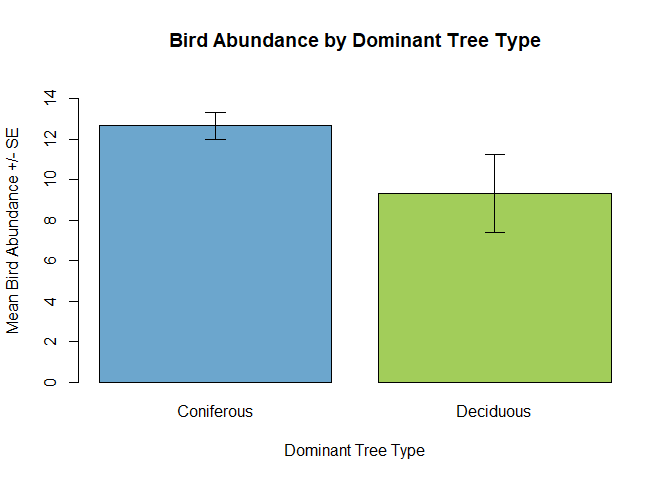

```r
plot.hab.mean <- barplot(hab.stat$mean.abun.hab ~ hab.stat$habitat,
                         xlab = "Dominant Tree Type",
                         ylab = "Mean Bird Abundance +/- SE",
                         ylim = c(0,15),
                         names.arg = c("Coniferous","Deciduous"),
                         col = c("skyblue3","darkolivegreen3"),
                         main= "Bird Abundance by Dominant Tree Type")
arrows(plot.hab.mean, hab.stat$mean.abun.hab - hab.stat$se,
       plot.hab.mean, hab.stat$mean.abun.hab + hab.stat$se,
       code=3, angle=90,length=0.1)
```

#### Statistics

##### Test for homogeneity of variance w/ Fligner Killeen

```r
fligner.test(replicates.abun$rep.abun~replicates.abun$habitat)
```

```
##
##  Fligner-Killeen test of homogeneity of variances
##
## data:  replicates.abun$rep.abun by replicates.abun$habitat
## Fligner-Killeen:med chi-squared = 2.4794, df = 1, p-value = 0.1153
```

**Variances are homogeneous**

##### Test for normality with Shapiro-Wilk

```r
# create coniferous and deciduous datasets
bird.rep.con <-replicates.abun %>%
  filter(habitat=="C")
bird.rep.dec <-replicates.abun %>%
  filter(habitat=="D")
# test for normality
shapiro.test(bird.rep.con$rep.abun)
```

```
##
##  Shapiro-Wilk normality test
##
## data:  bird.rep.con$rep.abun
## W = 0.91994, p-value = 0.505
```

```r
shapiro.test(bird.rep.dec$rep.abun)
```

```
##
##  Shapiro-Wilk normality test
##
## data:  bird.rep.dec$rep.abun
## W = 0.87157, p-value = 0.2325
```

**Abundances are normally distributed**

##### T-test

Running the t-test

```r
t.test(replicates.abun$rep.abun~replicates.abun$habitat, var.equal=TRUE)
```

```
##
##  Two Sample t-test
##
## data:  replicates.abun$rep.abun by replicates.abun$habitat
## t = 1.6222, df = 10, p-value = 0.1358
## alternative hypothesis: true difference in means between group C and group D is not equal to 0
## 95 percent confidence interval:
##  -1.245057  7.911723
## sample estimates:
## mean in group C mean in group D
##       12.666667        9.333333
```

**Variances are homogeneous** **Abundances are normally distributed** **p=0.1358 > 0.05. Difference is not significant**

### Urban vs Rural

#### Mean Abundance and Error

```r
urban.stat <- replicates.abun %>%
  group_by(urban) %>%
  summarize(mean.abun=mean(rep.abun),
            count = n(),
            sd=sd(rep.abun),
            se=sd/sqrt(count))
head(urban.stat)
```

```
## # A tibble: 2 × 5
##   urban mean.abun count    sd    se
##   <chr>     <dbl> <int> <dbl> <dbl>
## 1 high      12.8      6  4.07  1.66
## 2 low        9.17     6  2.71  1.11
```

##### Plot

[figure not shown]

```r
plot.urban.mean <- barplot(urban.stat$mean.abun ~ urban.stat$urban,
                         xlab = "",
                         ylab = "Mean Bird Abundance +/- SE",
                         ylim = c(0,15),
                         names.arg = c("Urban","Rural"),
                         col = c("lightcyan3","palegoldenrod"),
                         main= "Bird Abundance Rural vs. Urban Parks")
arrows(plot.hab.mean, hab.stat$mean.abun.hab - hab.stat$se,
       plot.hab.mean, hab.stat$mean.abun.hab + hab.stat$se,
       code=3, angle=90,length=0.1)
```

#### Statistics

##### Test for homogeneity of variance w/ Fligner Killeen

```r
fligner.test(replicates.abun$rep.abun~replicates.abun$urban)
```

```
##
##  Fligner-Killeen test of homogeneity of variances
##
## data:  replicates.abun$rep.abun by replicates.abun$urban
## Fligner-Killeen:med chi-squared = 0.043693, df = 1, p-value = 0.8344
```

**Variances are homogeneous**

##### Test for normality with Shapiro-Wilk

```r
# create rural and urban datasets
bird.urban.high <- replicates.abun %>%
  filter(urban=="high")
bird.urban.low <- replicates.abun %>%
  filter(urban=="low")
# test for normality
shapiro.test(bird.urban.high$rep.abun)
```

```
##
##  Shapiro-Wilk normality test
##
## data:  bird.urban.high$rep.abun
## W = 0.96202, p-value = 0.8351
```

```r
shapiro.test(bird.urban.low$rep.abun)
```

```
##
##  Shapiro-Wilk normality test
##
## data:  bird.urban.low$rep.abun
## W = 0.91335, p-value = 0.4588
```

**Abundances are normally distributed**

##### T-test

```r
t.test(replicates.abun$rep.abun~replicates.abun$urban, var.equal=TRUE)
```

```
##
##  Two Sample t-test
##
## data:  replicates.abun$rep.abun by replicates.abun$urban
## t = 1.8359, df = 10, p-value = 0.09624
## alternative hypothesis: true difference in means between group high and group low is not equal to 0
## 95 percent confidence interval:
##  -0.7834175  8.1167508
## sample estimates:
## mean in group high  mean in group low
##          12.833333           9.166667
```

**Variances are homogenous** **Abundances are normally distributed** **p=0.09624 > 0.05. Difference is not significant**

### Both Predictors - Abundance - 2x2 Bar Graph

No statistics tests required for this - just graph / effect size and interpretation of possible interaction effect

```r
factorial.stat <- bird.dat %>%
  group_by(habitat, urban, site, replicate) %>%
  summarise(total.site.abun=sum(abundance)) %>%
  group_by(site,habitat,urban) %>%
  summarise(mean.site.abun=mean(total.site.abun),
            count=n(),
            sd=sd(total.site.abun),
            se=sd/sqrt(count))
head(factorial.stat)
```

```
## # A tibble: 4 × 7
## # Groups:   site, habitat [4]
##   site  habitat urban mean.site.abun count    sd    se
##   <chr> <chr>   <chr>          <dbl> <int> <dbl> <dbl>
## 1 CEL   C       low             11.3     3 0.577 0.333
## 2 LHP   D       low              7       3 2     1.15
## 3 LS    C       high            14       3 1     0.577
## 4 MCR   D       high            11.7     3 6.03  3.48
```

#### Plot

```r
head(factorial.stat)
```

```
## # A tibble: 4 × 7
## # Groups:   site, habitat [4]
##   site  habitat urban mean.site.abun count    sd    se
##   <chr> <chr>   <chr>          <dbl> <int> <dbl> <dbl>
## 1 CEL   C       low             11.3     3 0.577 0.333
## 2 LHP   D       low              7       3 2     1.15
## 3 LS    C       high            14       3 1     0.577
## 4 MCR   D       high            11.7     3 6.03  3.48
```

```r
factorial.stat.box <- factorial.stat %>%
  ungroup %>%
  select(habitat,urban, mean.site.abun) %>%
  pivot_wider(names_from=habitat, values_from=mean.site.abun)
head(factorial.stat.box)
```

```
## # A tibble: 2 × 3
##   urban     C     D
##   <chr> <dbl> <dbl>
## 1 low    11.3   7
## 2 high   14    11.7
```

```r
# convert to data matrix for graphing side-by-side
factorial.stat.box1 <- factorial.stat.box %>%
  rename(Coniferous=C,Deciduous=D)
factor.stat.box.matrix <- data.matrix(factorial.stat.box1[,2:3])

# error matrix
error <- factorial.stat %>%
  ungroup %>%
  select(urban,habitat,se) %>%
  pivot_wider(names_from=habitat, values_from=se)
error1 <- data.matrix(error[,2:3])
head(error1)
```

```
##              C        D
## [1,] 0.3333333 1.154701
## [2,] 0.5773503 3.480102
```

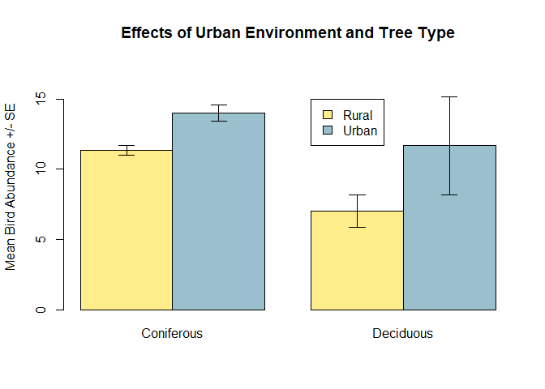

```r
# Plot

pretty <- c("lightgoldenrod1","lightblue3") # change colour scheme here

factorial.plot <- barplot(factor.stat.box.matrix,
                          beside=TRUE,
                          ylim=c(0,17.5),
                          ylab="Mean Bird Abundance +/- SE",
                          col=pretty,
                          space=c(0,.5),
                          main="Effects of Urban Environment and Tree Type")
# error bars
arrows(factorial.plot,factor.stat.box.matrix+error1,factorial.plot,factor.stat.box.matrix-error1,code=3, angle=90, length=0.1)
# legend
legend(3,15, legend=c("Rural","Urban"), fill=pretty)
```

#### Same thing but Reverse Predictors

Color = habitat, urban = x-axis

```r
head(factorial.stat)
```

```
## # A tibble: 4 × 7
## # Groups:   site, habitat [4]
##   site  habitat urban mean.site.abun count    sd    se
##   <chr> <chr>   <chr>          <dbl> <int> <dbl> <dbl>
## 1 CEL   C       low             11.3     3 0.577 0.333
## 2 LHP   D       low              7       3 2     1.15
## 3 LS    C       high            14       3 1     0.577
## 4 MCR   D       high            11.7     3 6.03  3.48
```

```r
factorial.stat.box2 <- factorial.stat %>%
  ungroup %>%
  select(habitat,urban, mean.site.abun) %>%
  pivot_wider(names_from=urban, values_from=mean.site.abun)
head(factorial.stat.box2)
```

```
## # A tibble: 2 × 3
##   habitat   low  high
##   <chr>   <dbl> <dbl>
## 1 C        11.3  14
## 2 D         7    11.7
```

```r
# convert to data matrix for graphing side-by-side
factorial.stat.box3 <- factorial.stat.box2 %>%
  rename(Rural=low,Urban=high)
factor.stat.box.matrix2 <- data.matrix(factorial.stat.box3[,2:3])

# error matrix
error1a <- factorial.stat %>%
  ungroup %>%
  select(urban,habitat,se) %>%
  pivot_wider(names_from=urban, values_from=se)
error1b <- data.matrix(error1a[,2:3])
head(error1b)
```

```
##            low      high
## [1,] 0.3333333 0.5773503
## [2,] 1.1547005 3.4801022
```

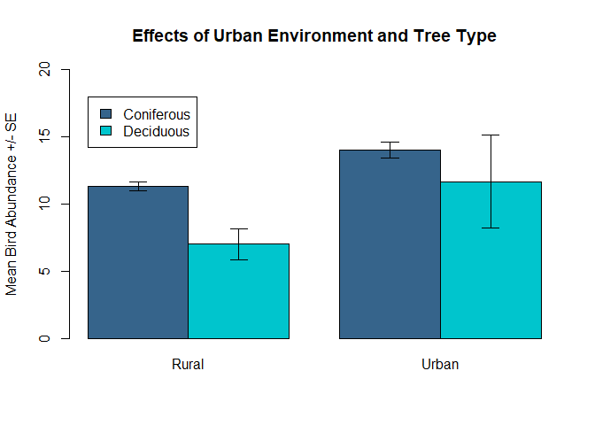

```r
# Plot

treecolors <- c("steelblue4","turquoise3") # change colour scheme here

factorial.plot2 <- barplot(factor.stat.box.matrix2,
                          beside=TRUE,
                          ylim=c(0,20),
                          ylab="Mean Bird Abundance +/- SE",
                          col=treecolors,
                          space=c(0,.5),
                          main="Effects of Urban Environment and Tree Type")
# error bars
arrows(factorial.plot2,factor.stat.box.matrix2+error1b,factorial.plot2,factor.stat.box.matrix2-error1b,code=3, angle=90, length=0.1)
# legend
legend(.5,18, legend=c("Coniferous","Deciduous"), fill=treecolors)
```

## Hill’s Numbers with vegan::renyi

Create list of hills numbers for each replicate

```r
hill.replicates <- bird.dat %>% group_by(replicate) %>%
  summarize(renyi(abundance,scales=c(0,1,2),hill=TRUE))
#write.csv(hill.replicates, "hills.num.csv", row.names=FALSE)
```

Send to Excel to format

## Rarefied Species Richness

First we need to check what the smallest number of individuals was that we saw in any given replicate

```r
bird.dat %>% group_by(replicate) %>%
  summarize(individuals=sum(abundance)) %>%
  arrange(individuals)
```

```
## # A tibble: 12 × 2
##    replicate individuals
##    <chr>           <int>
##  1 LHP2                5
##  2 MCR3                6
##  3 LHP1                7
##  4 LHP3                9
##  5 CEL2               11
##  6 CEL3               11
##  7 MCR1               11
##  8 CEL1               12
##  9 LS2                13
## 10 LS3                14
## 11 LS1                15
## 12 MCR2               18
```

n=5 is the smallest number of individuals in one replicate. This is our resampling number for rarefaction.

```r
replicates <- split(bird.dat,bird.dat$replicate)
rarefy.replicates <- vector(mode="integer",length = 12)
names(rarefy.replicates) <- names(replicates)

# rarefy all replicate subsets at n=5

for (i in 1:12) {
  rarefy.replicates[i]=rarefy(as.vector(replicates[[i]][[6]]),5)
}
head(rarefy.replicates)
```

```
##     CEL1     CEL2     CEL3     LHP1     LHP2     LHP3
## 2.098485 2.333333 1.000000 2.428571 2.000000 2.111111
```

```r
as.tibble(rarefy.replicates)
```

```
## # A tibble: 12 × 1
##    value
##    <dbl>
##  1  2.10
##  2  2.33
##  3  1
##  4  2.43
##  5  2
##  6  2.11
##  7  3.67
##  8  3.68
##  9  3.50
## 10  3.97
## 11  2.81
## 12  2
```

```r
# write.csv(rarefy.replicates,"rarefy.replicates.csv",row.names=TRUE)
# organize in excel and then re-imported

# import joined table from Excel
replicates.diversity <- read.csv("bird.all.hills.csv")
replicates.diversity
```

```
##    Site Replicate   habitat urban hill0 rarefyhill0    hill1    hill2
## 1   CEL      CEL1   Conifer   low     3    2.098485 2.057442 1.674419
## 2   CEL      CEL2   Conifer   low     3    2.333333 2.363083 2.050847
## 3   CEL      CEL3   Conifer   low     1    1.000000 1.000000 1.000000
## 4   LHP      LHP1 Deciduous   low     3    2.428571 2.217347 1.814815
## 5   LHP      LHP2 Deciduous   low     2    2.000000 1.649385 1.470588
## 6   LHP      LHP3 Deciduous   low     3    2.111111 1.981272 1.588235
## 7    LS       LS1   Conifer  high     7    3.672328 5.551608 4.411765
## 8    LS       LS2   Conifer  high     7    3.683761 5.432551 4.333333
## 9    LS       LS3   Conifer  high     6    3.499500 4.826383 3.920000
## 10  MCR      MCR1 Deciduous  high     6    3.969697 5.585609 5.260870
## 11  MCR      MCR2 Deciduous  high     6    2.811275 3.564268 2.454545
## 12  MCR      MCR3 Deciduous  high     2    2.000000 1.889882 1.800000
```

```r
replicates.diversity.ln <- replicates.diversity %>%
  mutate(rarefyhill0.ln=log(rarefyhill0), .after=rarefyhill0)
replicates.diversity.ln
```

```
##    Site Replicate   habitat urban hill0 rarefyhill0 rarefyhill0.ln    hill1
## 1   CEL      CEL1   Conifer   low     3    2.098485      0.7412156 2.057442
## 2   CEL      CEL2   Conifer   low     3    2.333333      0.8472979 2.363083
## 3   CEL      CEL3   Conifer   low     1    1.000000      0.0000000 1.000000
## 4   LHP      LHP1 Deciduous   low     3    2.428571      0.8873032 2.217347
## 5   LHP      LHP2 Deciduous   low     2    2.000000      0.6931472 1.649385
## 6   LHP      LHP3 Deciduous   low     3    2.111111      0.7472144 1.981272
## 7    LS       LS1   Conifer  high     7    3.672328      1.3008257 5.551608
## 8    LS       LS2   Conifer  high     7    3.683761      1.3039342 5.432551
## 9    LS       LS3   Conifer  high     6    3.499500      1.2526202 4.826383
## 10  MCR      MCR1 Deciduous  high     6    3.969697      1.3786898 5.585609
## 11  MCR      MCR2 Deciduous  high     6    2.811275      1.0336379 3.564268
## 12  MCR      MCR3 Deciduous  high     2    2.000000      0.6931472 1.889882
##       hill2
## 1  1.674419
## 2  2.050847
## 3  1.000000
## 4  1.814815
## 5  1.470588
## 6  1.588235
## 7  4.411765
## 8  4.333333
## 9  3.920000
## 10 5.260870
## 11 2.454545
## 12 1.800000
```

### Habitat

#### Mean Rarefied Richness and Error

```r
rarefy.stat.hab <- replicates.diversity %>%
  group_by(habitat) %>%
  summarize(mean.rarefy=mean(rarefyhill0),
            count = n(), sd=sd(rarefyhill0),
            se=sd/sqrt(count))
head(rarefy.stat.hab)
```

```
## # A tibble: 2 × 5
##   habitat   mean.rarefy count    sd    se
##   <chr>           <dbl> <int> <dbl> <dbl>
## 1 Conifer          2.71     6 1.09  0.445
## 2 Deciduous        2.55     6 0.761 0.311
```

##### Plot

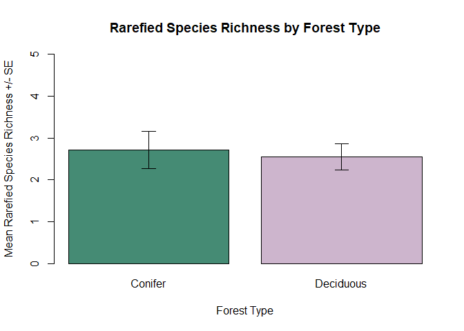

```r
plot.rarefy.hab <- barplot(rarefy.stat.hab$mean.rarefy ~ rarefy.stat.hab$habitat,
                         xlab = "Forest Type",
                         cex.lab = 1,
                         ylab = "Mean Rarefied Species Richness +/- SE",
                         ylim = c(0,5),
                         names.arg = c("Conifer","Deciduous"),
                         col = c("aquamarine4","thistle3"),
                         main= "Rarefied Species Richness by Forest Type")
arrows(plot.rarefy.hab, rarefy.stat.hab$mean.rarefy - rarefy.stat.hab$se,
       plot.hab.mean, rarefy.stat.hab$mean.rarefy + rarefy.stat.hab$se,
       code=3, angle=90,length=0.1)
```

#### Statistics

##### Test for homogeneity of variance w/ Fligner Killeen

```r
fligner.test(replicates.diversity$rarefyhill0~replicates.diversity$habitat)
```

```
##
##  Fligner-Killeen test of homogeneity of variances
##
## data:  replicates.diversity$rarefyhill0 by replicates.diversity$habitat
## Fligner-Killeen:med chi-squared = 3.4118, df = 1, p-value = 0.06473
```

**Variances are homogeneous, barely**

##### Test for normality with Shapiro-Wilk

```r
diversity.con <- replicates.diversity %>%
  filter(habitat=="Conifer")
diversity.dec <- replicates.diversity %>%
  filter(habitat=="Deciduous")
shapiro.test(diversity.con$rarefyhill0)
```

```
##
##  Shapiro-Wilk normality test
##
## data:  diversity.con$rarefyhill0
## W = 0.8681, p-value = 0.2187
```

```r
shapiro.test(diversity.dec$rarefyhill0)
```

```
##
##  Shapiro-Wilk normality test
##
## data:  diversity.dec$rarefyhill0
## W = 0.80008, p-value = 0.05888
```

*both greater than p>0.05, barely*

##### T-test

```r
t.test(replicates.diversity$rarefyhill0~replicates.diversity$habitat, var.equal=TRUE)
```

```
##
##  Two Sample t-test
##
## data:  replicates.diversity$rarefyhill0 by replicates.diversity$habitat
## t = 0.29693, df = 10, p-value = 0.7726
## alternative hypothesis: true difference in means between group Conifer and group Deciduous is not equal to 0
## 95 percent confidence interval:
##  -1.047935  1.370186
## sample estimates:
##   mean in group Conifer mean in group Deciduous
##                2.714568                2.553442
```

**Difference is not significant. (t=0.29693, df= 10, p=0.7726**)

### Rural vs. Urban

#### Mean Rarefied Richness and Error

```r
rarefy.stat.urban <- replicates.diversity %>%
  group_by(urban) %>%
  summarize(mean.rarefy=mean(rarefyhill0),
            count = n(), sd=sd(rarefyhill0),
            se=sd/sqrt(count))
head(rarefy.stat.urban)
```

```
## # A tibble: 2 × 5
##   urban mean.rarefy count    sd    se
##   <chr>       <dbl> <int> <dbl> <dbl>
## 1 high         3.27     6 0.735 0.300
## 2 low          2.00     6 0.513 0.209
```

##### Plot

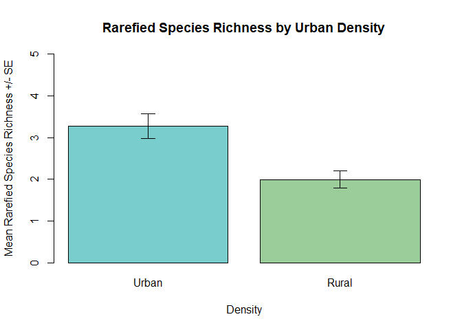

```r
plot.rarefy.urban <- barplot(rarefy.stat.urban$mean.rarefy ~ rarefy.stat.urban$urban,
                         xlab = "Density",
                         ylab = "Mean Rarefied Species Richness +/- SE",
                         ylim = c(0,5),
                         names.arg = c("Urban","Rural"),
                         col = c("darkslategray3","darkseagreen3"),
                         main= "Rarefied Species Richness by Urban Density")
arrows(plot.rarefy.urban, rarefy.stat.urban$mean.rarefy - rarefy.stat.urban$se,
       plot.rarefy.urban, rarefy.stat.urban$mean.rarefy + rarefy.stat.urban$se,
       code=3, angle=90,length=0.1)
```

#### Statistics

##### Test for homogeneity of variance w/ Fligner Killeen

```r
fligner.test(replicates.diversity.ln$rarefyhill0~replicates.diversity$urban)
```

```
##
##  Fligner-Killeen test of homogeneity of variances
##
## data:  replicates.diversity.ln$rarefyhill0 by replicates.diversity$urban
## Fligner-Killeen:med chi-squared = 0.48169, df = 1, p-value = 0.4877
```

**Variances are homogeneous**

##### Test for normality with Shapiro-Wilk

```r
diversity.high <- replicates.diversity %>%
  filter(urban=="high")
diversity.low <- replicates.diversity %>%
  filter(urban=="low")
shapiro.test(diversity.high$rarefyhill0)
```

```
##
##  Shapiro-Wilk normality test
##
## data:  diversity.high$rarefyhill0
## W = 0.86363, p-value = 0.202
```

```r
shapiro.test(diversity.low$rarefyhill0)
```

```
##
##  Shapiro-Wilk normality test
##
## data:  diversity.low$rarefyhill0
## W = 0.77968, p-value = 0.03829
```

*normality is violated for urban=low*

##### T-test

```r
t.test(replicates.diversity$rarefyhill0~replicates.diversity$urban, var.equal=TRUE)
```

```
##
##  Two Sample t-test
##
## data:  replicates.diversity$rarefyhill0 by replicates.diversity$urban
## t = 3.4919, df = 10, p-value = 0.005804
## alternative hypothesis: true difference in means between group high and group low is not equal to 0
## 95 percent confidence interval:
##  0.4623552 2.0926647
## sample estimates:
## mean in group high  mean in group low
##            3.27276            1.99525
```

What is the skew and kurtosis?

```r
skewness(diversity.low$rarefyhill0)
```

```
## [1] -1.399386
```

```r
kurtosis(diversity.low$rarefyhill0)
```

```
## [1] 3.5638
```

# Questions

## Rarefied Species Richness

What does it mean when say “ideally per replicate using the smallest sample”?

# Notes

## Bohemian Waxwings

Based off an average flock size of 50 and rounding up to nearest 50. Bohemian Scaled count = CEILING(Bohemian/50,1)

https://www.allaboutbirds.org/guide/Bohemian_Waxwing/lifehistory#